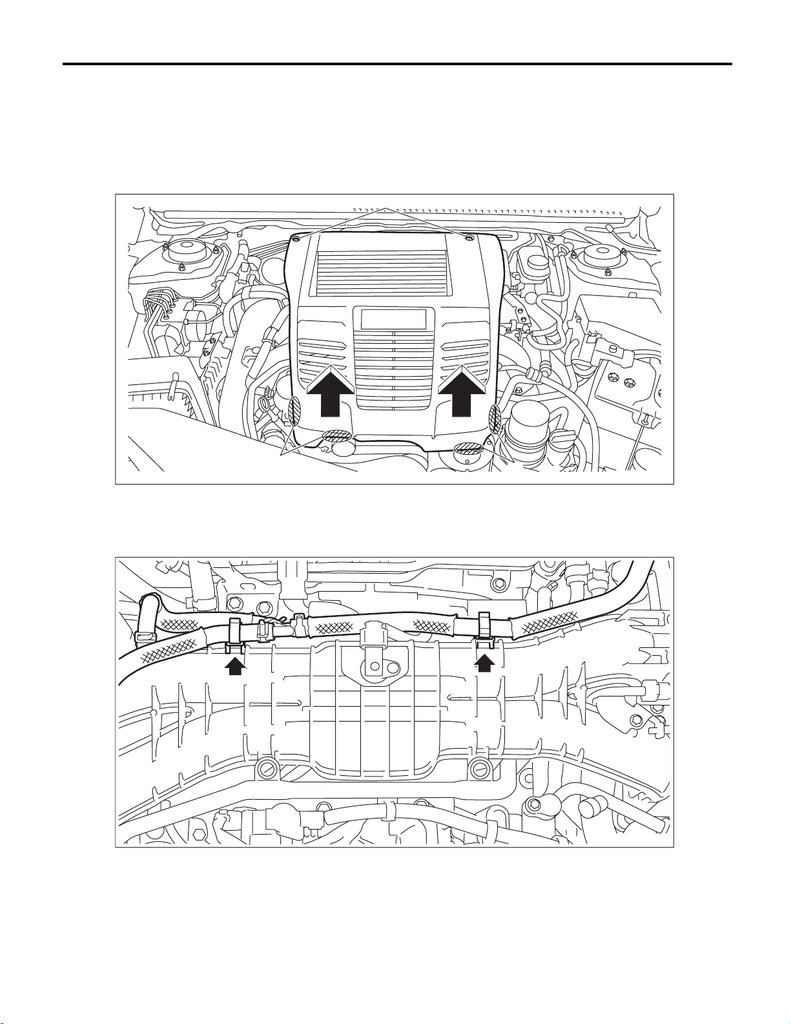

EC(w/o STI)-40

EGR Cooler

EMISSION CONTROL (AUX. EMISSION CONTROL DEVICES)

8. EGR Cooler

A: REMOVAL

1) Remove the collector cover.

(1) Remove the clips (A).

(2) Hold the shaded area (B) by hand and carefully pull the RH side (C) upward.

(3) Hold the shaded area (D) by hand and carefully pull the LH side (E) upward.

2) Disconnect the ground terminal from battery sensor. <Ref. to NT-5, BATTERY, NOTE, Note.>

3) Remove the intercooler. <Ref. to IN(w/o STI)-38, REMOVAL, Intercooler.>

4) Remove the clip securing the brake booster vacuum hose to the intake manifold, and move the brake

booster vacuum hose at the locations that do not interfere operation.

5) Lift up the vehicle.

6) Drain engine coolant. <Ref. to CO(w/o STI)-13, DRAINING OF ENGINE COOLANT, REPLACEMENT,

Engine Coolant.>

EX-03204

(A)

(B)

(C)

(E)

(D)

EC-03455

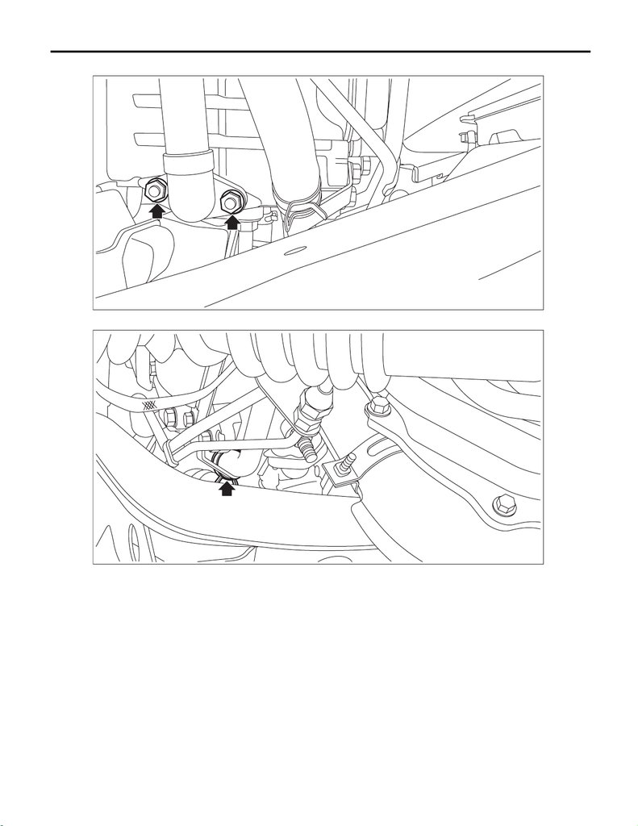

EC(w/o STI)-41

EGR Cooler

EMISSION CONTROL (AUX. EMISSION CONTROL DEVICES)

8) Disconnect the water hose A from the water pipe RH.

9) Lower the vehicle.

EC-03296

EC-03264

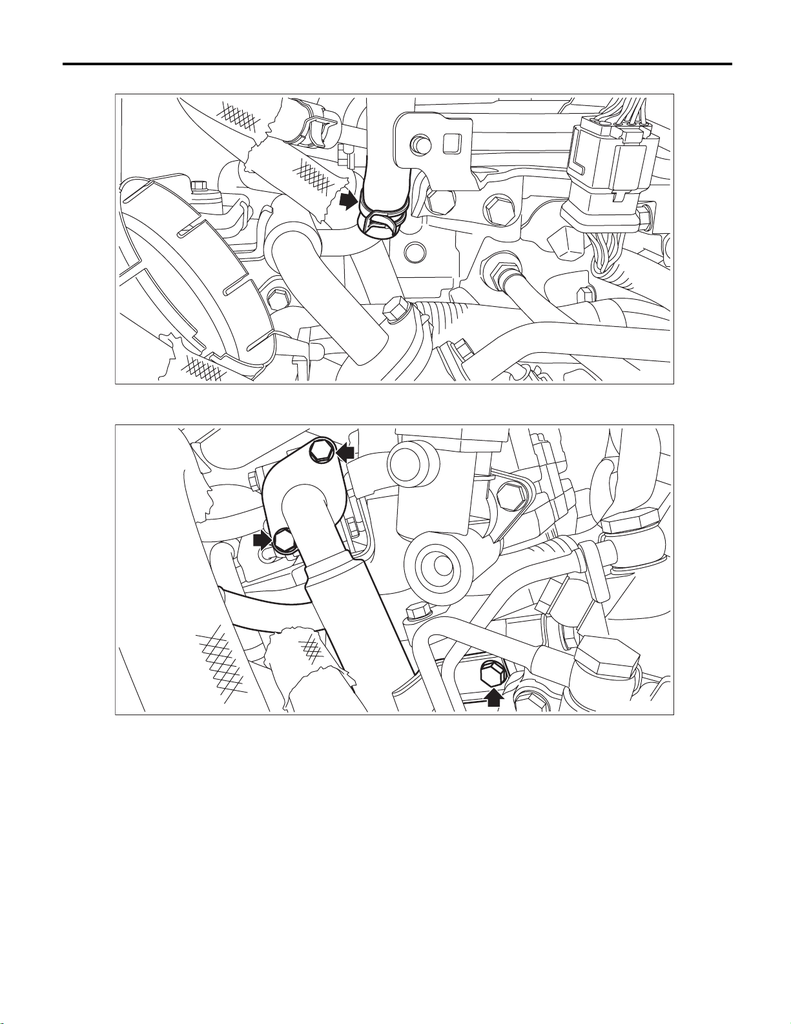

EC(w/o STI)-42

EGR Cooler

EMISSION CONTROL (AUX. EMISSION CONTROL DEVICES)

10) Disconnect the engine coolant inlet hose (CVT model) or water hose B (MT model) from the EGR cooler.

11) Remove the bolts which secure the EGR cooler to the EGR control valve and cylinder head RH, and re-

move the EGR cooler.

EC-03259

EC-03263

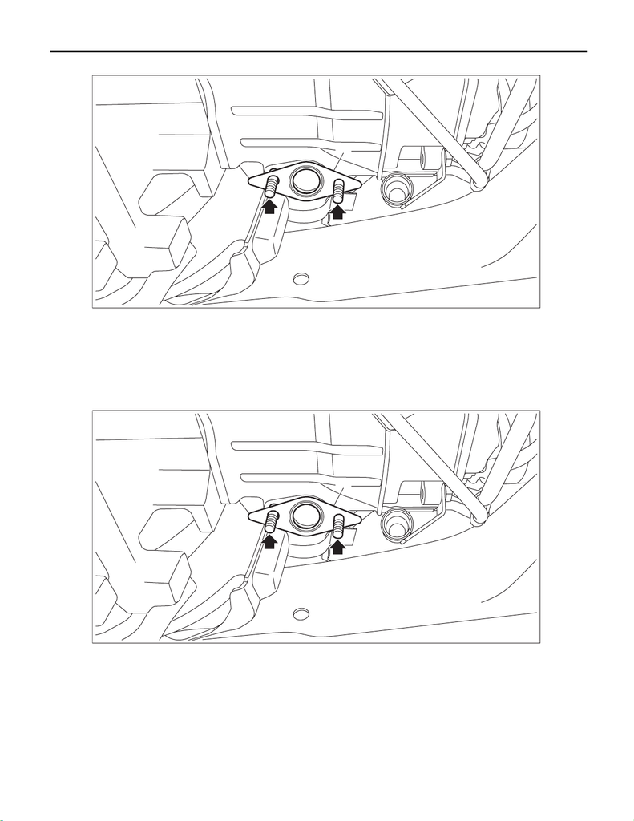

EC(w/o STI)-43

EGR Cooler

EMISSION CONTROL (AUX. EMISSION CONTROL DEVICES)

12) Remove the gasket (A) from the stud bolt, and remove the stud bolt from the cylinder head RH.

B: INSTALLATION

1) Install the stud bolt to the cylinder head RH, and set the gasket (A) to the stud bolt.

NOTE:

Use a new stud bolt and gasket.

Tightening torque:

6.4 N·m (0.7 kgf-m, 4.7 ft-lb)

2) Lower the vehicle.

EC-03262

(A)

EC-03262

(A)

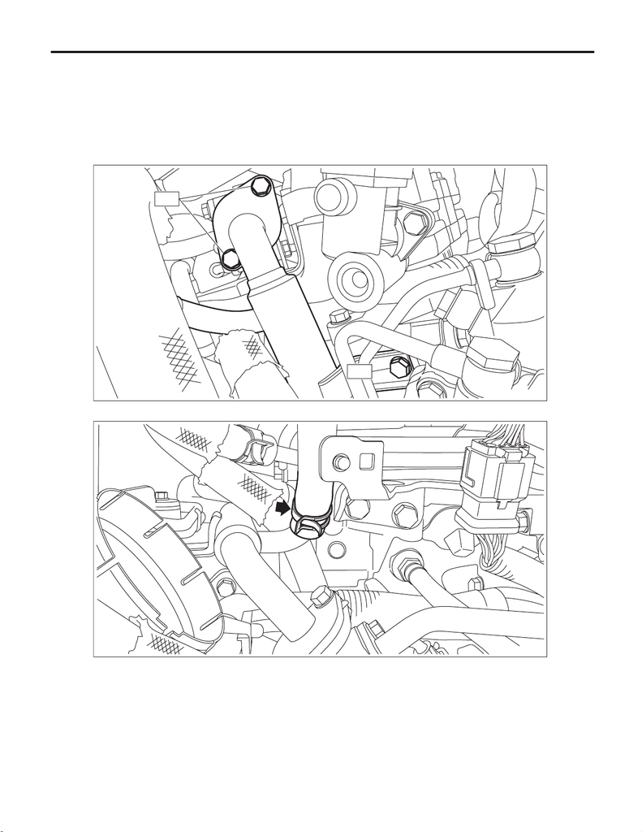

EC(w/o STI)-44

EGR Cooler

EMISSION CONTROL (AUX. EMISSION CONTROL DEVICES)

3) Set the EGR cooler to the EGR control valve and cylinder head RH, and install the bolts which secure the

EGR cooler to the EGR control valve and cylinder head RH.

NOTE:

Use a new gasket.

Tightening torque:

T1: 6.4 N·m (0.7 kgf-m, 4.7 ft-lb)

T2: 19 N·m (1.9 kgf-m, 14.0 ft-lb)

4) Connect the engine coolant inlet hose (CVT model) or water hose B (MT model) to the EGR cooler.

5) Lift up the vehicle.

EC-03279

T2

T1

EC-03259

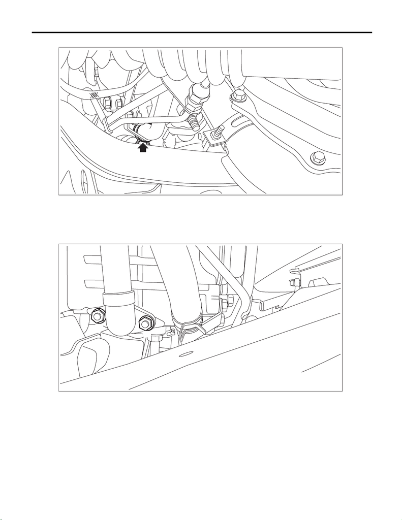

EC(w/o STI)-45

EGR Cooler

EMISSION CONTROL (AUX. EMISSION CONTROL DEVICES)

6) Connect the water hose A to the water pipe RH.

7) Install the EGR cooler to the cylinder block RH.

(1) Tighten the nuts which secure the EGR cooler to the cylinder block RH in numerical order as shown

in the figure.

Tightening torque:

9 N·m (0.9 kgf-m, 6.6 ft-lb)

EC-03264

EC-03297

(1)

(2)

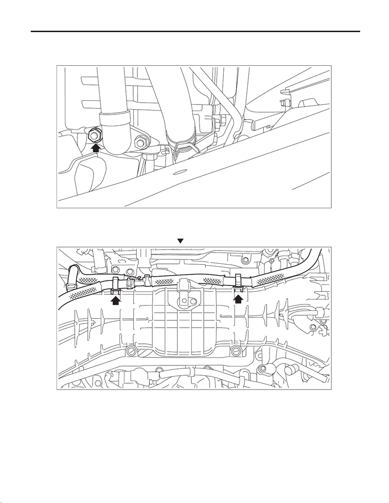

EC(w/o STI)-46

EGR Cooler

EMISSION CONTROL (AUX. EMISSION CONTROL DEVICES)

(2) Retighten the nut shown in the figure.

Tightening torque:

9 N·m (0.9 kgf-m, 6.6 ft-lb)

8) Lower the vehicle.

9) Install the clip which secures the brake booster vacuum hose to the intake manifold.

NOTE:

Install the clip to the position of alignment mark of intake manifold.

10) Install the intercooler. <Ref. to IN(w/o STI)-41, INSTALLATION, Intercooler.>

11) Connect the ground terminal to battery sensor. <Ref. to NT-5, BATTERY, NOTE, Note.>

12) Fill engine coolant. <Ref. to CO(w/o STI)-14, FILLING OF ENGINE COOLANT, REPLACEMENT, En-

gine Coolant.>

13) Install the collector cover.

EC-03298

EC-03455

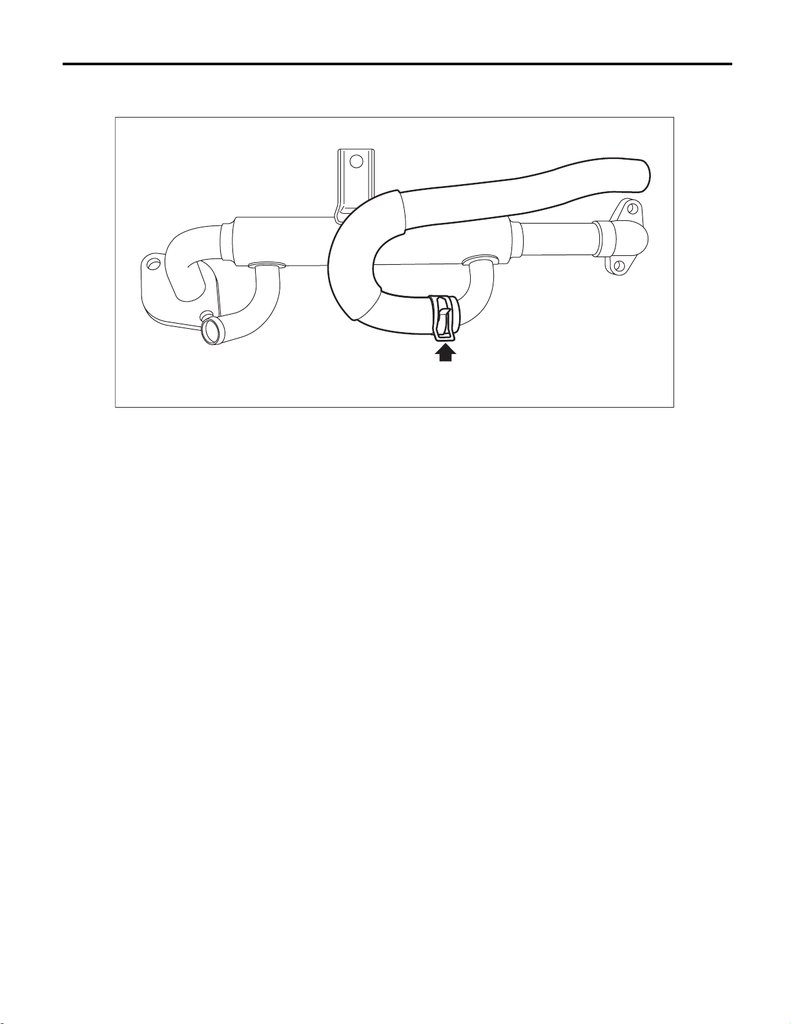

EC(w/o STI)-47

EGR Cooler

EMISSION CONTROL (AUX. EMISSION CONTROL DEVICES)

C: DISASSEMBLY

Remove the water hose A from EGR cooler.

D: ASSEMBLY

Assemble in the reverse order of disassembly.

E: INSPECTION

1) Check that the EGR cooler has no deformation, cracks or other damages.

2) Check that the water hose has no cracks, damage or loose part.

EC-03145